# R Open Labs: Exploring Data Part 2

## Missing and Special Values in R

### Missing Values in R: `NA` and `NULL`

R encodes missing values (e.g. blanks in your underlying dataset) as `NA`.

```r
my_data <- data.frame(name=c("John","Jane","Jack"),
                      age=c(42,65,NA))
print(my_data)
```

```
##   name age
## 1 John  42
## 2 Jane  65
## 3 Jack  NA
```

In the example above, we don’t know the age of Jack, though we do know the ages of John and Jane. Many of R’s basic functions need specific instructions on how to handle NAs. For example:

```r
mean(my_data$age)
```

```
## [1] NA
```

**Exercise** Inspect the help page for `mean` to get the actual mean for `my_data$age`.

R also uses `NULL` to encode missing objects. This is subtly different from missing values.

```r
a <- NA
b <- NULL
print(a)
```

```
## [1] NA
```

```r
print(b)
```

[output not shown]

```r
length(a)
```

```
## [1] 1
```

```r
length(b)
```

```
## [1] 0
```

The object `a` has one value, albiet missing, whereas the object `b` contains nothing at all.

## Identifying missing/special values

We often need to find these missing values to see if they make sense or if they indicate some sort of problem in our data. R has a specific set of functions to select `NA` values; unfortunately some of your first guesses don’t work!

```r
a <- c(1,2,3,4,5,NA,7)
which(a==NA)
```

```
## integer(0)
```

Instead, you need to use the `is.na`, `is.null`, and `is.finite`/`is.infinite`.

```r
is.na(a)
```

```
## [1] FALSE FALSE FALSE FALSE FALSE  TRUE FALSE
```

```r
b <- NULL
is.null(b)
```

```
## [1] TRUE
```

```r
c <- 5/0
is.finite(c)
```

```
## [1] FALSE
```

## Exploring Data Frames with NAs

There are also important functions to make it easier to apply these to dataframes. Let’s load in the data from last week’s Open Lab.

```r
data_url <- "http://guides.lib.unc.edu/ld.php?content_id=40263741"
airbnb <- read.csv(url(data_url))
head(airbnb)
```

```
##         id                                               name
## 1  4873463                 Cozy Pied-a-Terre, the Heart of DC
## 2 16736650      Large, welcoming studio in a central location
## 3 14999877       Newly Renovated Apartment in the Heart of DC
## 4  5955860                      Spacious Dupont Circle Condo
## 5 15655208 Luxury historic rowhouse; Adams Morgan/Dupont/UStr
## 6  4022565                Dupont, Adams Morgan, U Townhouse 3
##   property_type       room_type accommodates bathrooms bedrooms price
## 1     Apartment Entire home/apt            3       1.0        0    95
## 2     Apartment Entire home/apt            2       1.0        0   200
## 3     Apartment Entire home/apt            2       1.0        1   100
## 4     Apartment Entire home/apt            3       1.0        1   129
## 5     Townhouse Entire home/apt            4       2.5        2   500
## 6     Apartment    Private room            2       2.5        1   110
##   extra_people minimum_nights number_of_reviews review_scores_rating
## 1           10              2                29                   94
## 2            0              1                 2                   90
## 3            0             27                 0                   NA
## 4           50              2                79                   85
## 5            0              2                 1                  100
## 6           15              6                 7                   97
##   cancellation_policy reviews_per_month
## 1            flexible              1.01
## 2            flexible              0.55
## 3            moderate                NA
## 4            flexible              3.13
## 5              strict              1.00
## 6              strict              0.23
```

Notice there are some missing values in the review_scores_rating and reviews_per_month columns, even within the first six rows. We can check which values of review_scores_rating are `NA` with `is.na`.

```r
sum(is.na(airbnb$review_scores_rating)) #summing a logical (TRUE/FALSE) vector counts the number of TRUE values
```

```
## [1] 2207
```

```r
dim(airbnb)
```

```
## [1] 7788   14
```

We can check all of our columns using R’s `colSum` to sum all of the columns at the same time.

```r
colSums(is.na(airbnb))
```

```
##                   id                 name        property_type
##                    0                    0                    0
##            room_type         accommodates            bathrooms
##                    0                    0                   14
##             bedrooms                price         extra_people
##                   14                    0                    0
##       minimum_nights    number_of_reviews review_scores_rating
##                    0                    0                 2207
##  cancellation_policy    reviews_per_month
##                    0                 2128
```

Since we see that only four columns have missing values, we could identify all of them with

```r
airbnb_nas <- airbnb[(is.na(airbnb$bathrooms) | is.na(airbnb$bedrooms) | is.na(airbnb$review_scores_rating) | is.na(airbnb$reviews_per_month)),]
dim(airbnb_nas)
```

```
## [1] 2229   14
```

Fortunately, there are easier ways:

- `complete.cases` returns a logical vector indicating whether or not an entire row of a dataset contains any missing values. You can also use this function on a subset of columns to determine if only those columns are complete
- `na.omit` returns a new dataframe with only the complete cases (as identified above)

We’ll explore these more in the exercises!

## Basic Plots

Plots are a vital tool for exploratory data analysis.

### Histograms

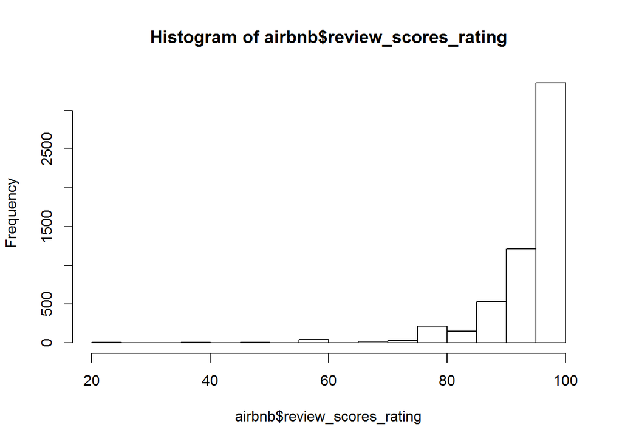

```r
hist(airbnb$review_scores_rating)
```

*Reminder* Remember to use `?` to read the documentation for new functions. This is particularly useful for plots as there are many parameters you can control (e.g. titles, axis limits, number of bars in a histogram, etc.)

**Note** We can produce a smoothed histogram using `plot(density())`. Notice that we need to explicitly tell R how to handle the `NA`s!

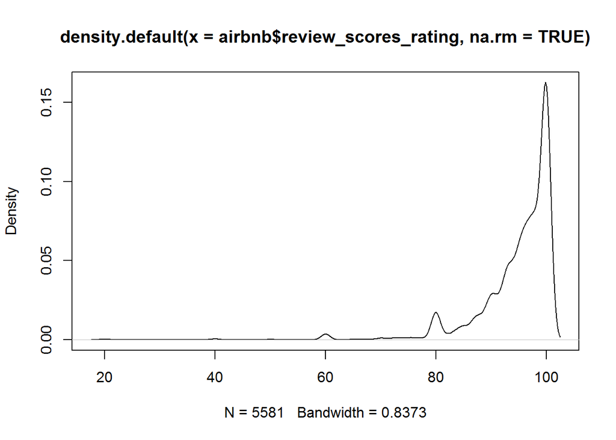

```r
plot(density(airbnb$review_scores_rating, na.rm=TRUE))
```

### Bar Charts

Bar charts, via `barplot` provide a graphical alternative to tables, and conveniently take tables as arguments.

```r
tab <- table(airbnb$room_type)
print(tab)
```

```
##
## Entire home/apt    Private room     Shared room
##            5326            2262             200
```

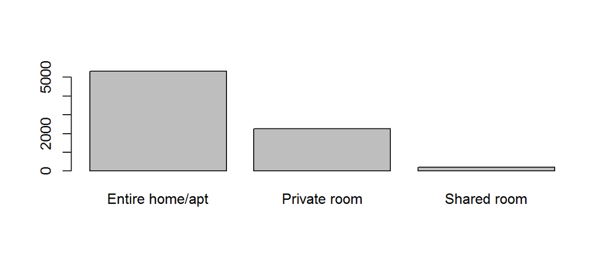

```r
barplot(tab)
```

### Scatterplots

Scatterplots allow us to examine the relationship between two continuous variables. We can use `plot` with two numeric values to create a scatterplot.

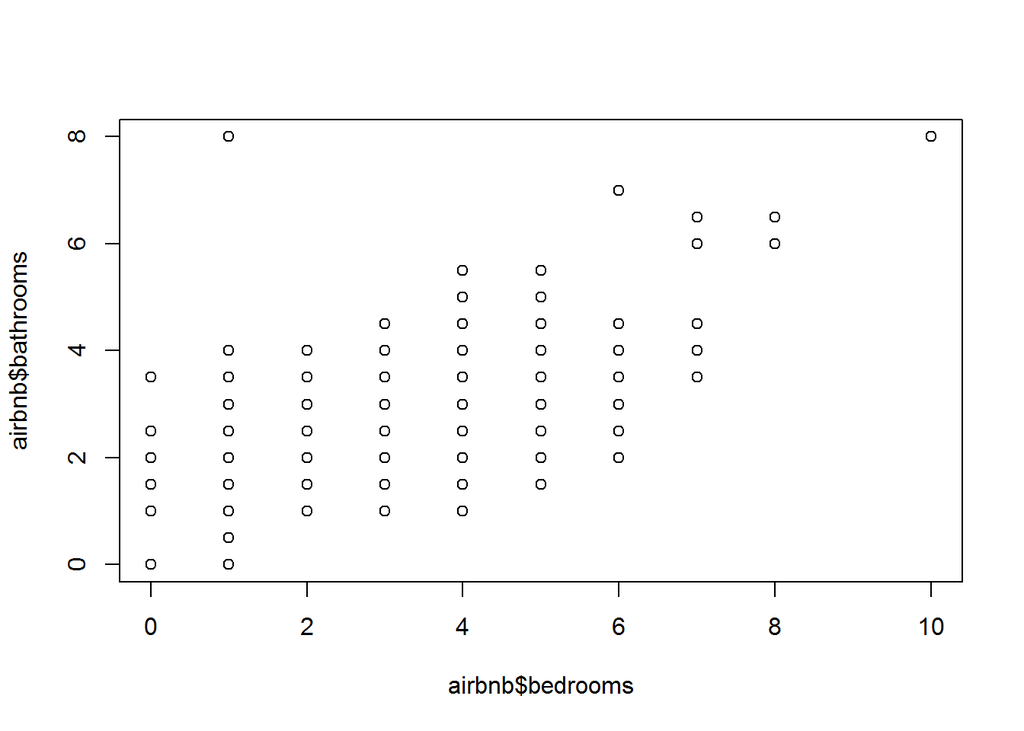

```r
plot(airbnb$bedrooms,airbnb$bathrooms)
```

## ggplot2

More advanced plots in R are often created using the `ggplot2` library.

First you’ll need to install the library (if you haven’t already), then activate it.

```r
#install.packages("ggplot2")
library(ggplot2)
```

Plots are constructed by setting up a plotting area with `ggplot` and then adding geometric objects (e.g. `geom_bar`,`geom_text`,`geom_point`) with `+`.

For example, we can scatter number_of_reviews vs review_scores_rating as follows:

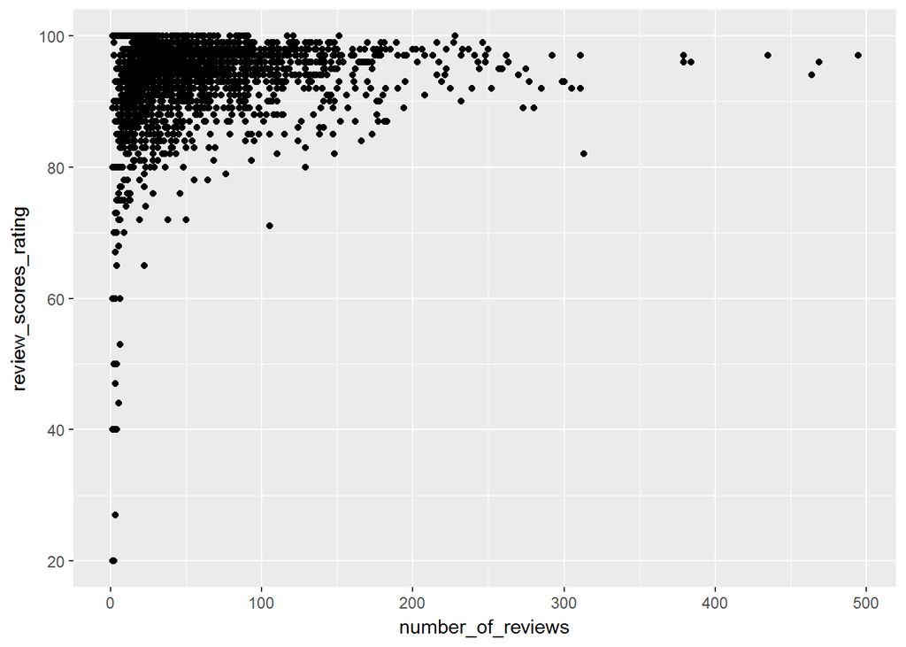

```r
ggplot(data=airbnb,aes(x=number_of_reviews,y=review_scores_rating))+
  geom_point()
```

We can also recreate our barplot above as:

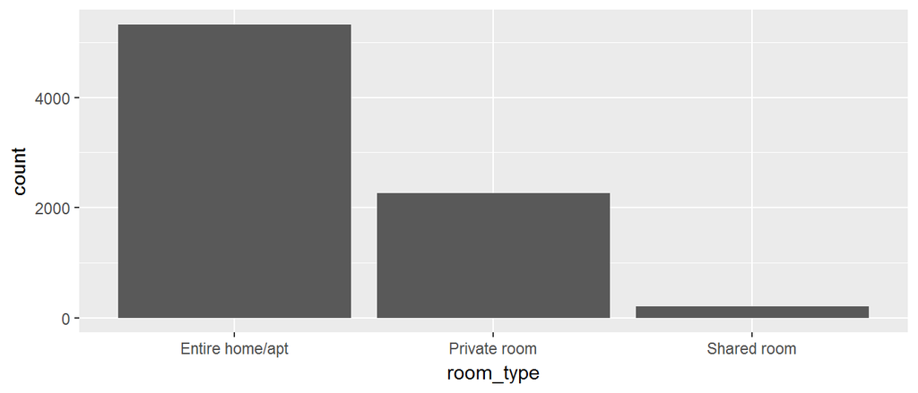

```r
ggplot(data=airbnb,aes(x=room_type))+
  geom_bar()
```

We can then further customize the plot with additional ggplot functions.

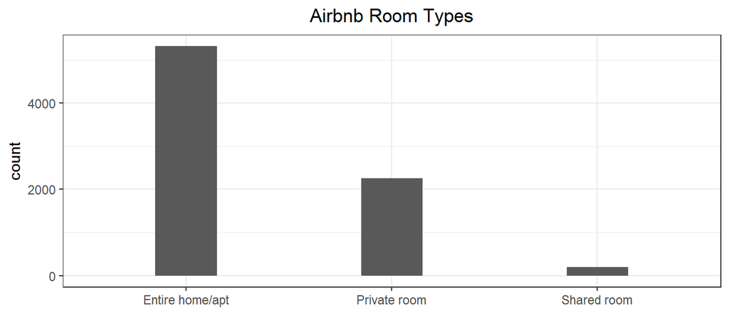

```r
ggplot(data=airbnb,aes(x=room_type))+
  geom_bar(width=0.3)+
  ggtitle("Airbnb Room Types")+
  theme_bw()+
  theme(axis.title.x=element_blank(),
        plot.title = element_text(hjust = 0.5))
```

We’ll cover more `ggplot2` in future Open Labs.

## Exercises

1. Create a new dataframe derived from `airbnb` without missing values in review_scores_rating and reviews_per_month.
2. Create a two-way barplot with grouped bars (not stacked) showing the breakdown of room_types by cancellation policy as below. (You do not need to have a legend).

You’ll need to:

- use a two-way table as your argument (order will be important - use trial and error!)
- examine the help for `barplot` to see prevent stacked bars

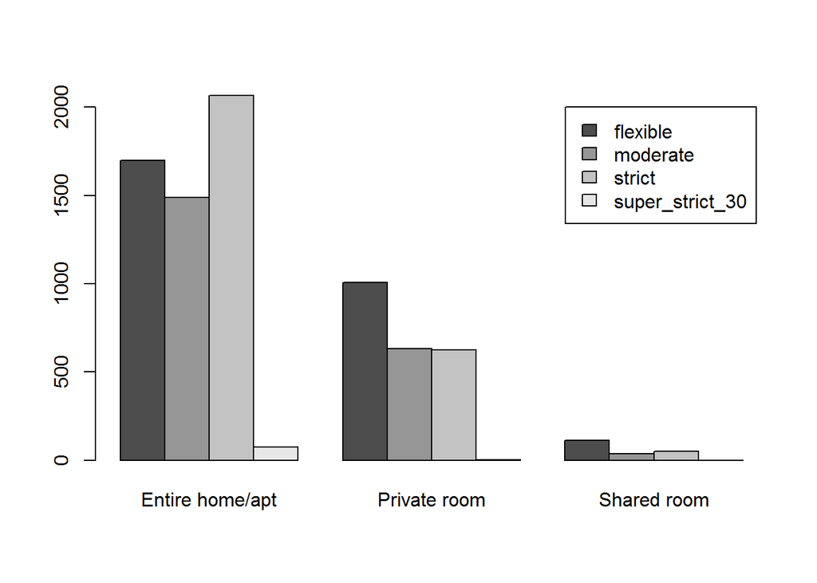

3. Use a scatterplot (with `plot`) to examine the relationship between reviews_per_month and bedrooms. Do more bedrooms seem to correlate with more or less reviews per month?
4. Recreate the plot from 3. using `ggplot2`.

[Let us know what you think of this lesson!](https://unc.az1.qualtrics.com/jfe/form/SV_8e1zRY2rlFUYBMx)